RAE-CEA–21P27

# **Relatório de Análise Estatística sobre o Projeto:**

“Emergência e Desenvolvimento da Ação Manipulativa de Apertar em bebês de 1 a 3 meses de idade”

Mariana Almeida Luís Gustavo Esteves Renata Massami Hirota Giovanna Vendeiro Vilar

#### São Paulo, novembro de 2021

# Centro de Estatística Aplicada - CEA - USP

**TÍTULO:** Relatório de Análise Estatística sobre o Projeto: “Emergência e Desenvolvimento da Ação Manipulativa de Apertar em bebês de 1 a 3 meses de idade”

**PESQUISADORA:** Priscilla A. M. Ferronato

**ORIENTADORA:**

**INSTITUIÇÃO:** Faculdade de Filosofia e Ciências Humanas da Universidade de São Paulo

**FINALIDADE DO PROJETO:** Publicação

**RESPONSÁVEIS PELA ANÁLISE:**  
Mariana Almeida  
Luís Gustavo Esteves  
Renata Massami Hirota  
Giovanna Vendeiro Vilar

**REFERÊNCIA DESTE TRABALHO:** ALMEIDA, M.C.; ESTEVES, L.G.; HIROTA, R.M.; VILAR, G.V. **Relatório de análise estatística sobre o projeto: “Emergência e Desenvolvimento da Ação Manipulativa de Apertar em bebês de 1 a 3 meses de idade”**. São Paulo, IME-USP, 2021. (RAE–CEA-21P27)

# 1 Resumo

# 2 Introdução

O estudo da ação manipulativa em bebês é uma forma de entender o desenvolvimento humano durante os primeiros meses de vida. Esse processo está relacionado ao descobrimento do próprio corpo pelo sujeito, bem como à influência do ambiente ao seu redor. De acordo com a Fundação Oswaldo Cruz (Fiocruz, 2019) “ O desenvolvimento infantil e a plasticidade cerebral são maiores nos primeiros anos de vida. Sendo assim, quaisquer perturbações no ambiente ou no indivíduo impactam substancialmente na aquisição das habilidades motoras e cognitivas”. Portanto, um projeto descrito no presente relatório conjuntamente com as análises que serão realizados contribuem na caracterização do desenvolvimento infantil, auxiliando no processo de entender novas formas de estimular o potencial ativo dos recém-nascidos em seus primeiros meses de vida. Salienta-se que o estudo tem como premissa a definição de que o comportamento de bebês ao nascer é ativo (voluntário) e não reflexo (involuntário). Conforme apontado pelas estudiosas (Haywood;Getchell, 2004), os reflexos representam apenas uma pequena parte do comportamento motor inicial dos indivíduos. Além disso, a literatura também aponta (Kawai, Savelsbergh, Wimmers, 1999) que os movimentos expontâneos (voluntários) parecem ser influenciados por restrições ambientais. De modo geral, o intuito do trabalho é investigar a emergência e desenvolvimento do comportamento voluntário das mãos em bebês de até três meses de idade, com base em alguns cenários experimentais.

# 3 Objetivo(s)

O objetivo principal do trabalho é entender a emergência e desenvolvimento do comportamento voluntário das mãos em bebês de até três meses de idade, com base em alguns cenários experimentais. A finalidade da análise estatística pode ser resumida nos seguintes tópicos:

1. Descrever o comportamento de apertar ao longo dos três primeiros meses após o nascimento;
2. verificar se bebês de um a três meses são capazes de identificar a existência de um relacionamento entre o seu próprio comportamento de apertar e alterações no contexto ambiental. Em outras palavras, o bebê identifica a relação entre a sua ação de apertar e um determinado acontecimento no ambiente?;
3. Identificar se as relações do comportamento manual com os eventos ambientais se alteram ao longo de três sessões de prática na situação experimental. Ou seja, há indicíos de que há aprendizado ao longo dos dias de experimento?

# 4 Descrição do estudo

## 4.1 Participantes

O estudo foi realizado de maneira presencial em três sessões individuais, dentro de um período de 7 dias, entre a pesquisadora e cada um dos participantes. Consistiu em apresentar aos bebês quatro condições experimentais e registrar, para cada uma, dados de pressão palmar relacionados aos apertos que os bebês realizaram sobre um equipamento com sensor de pressão colocado na palma de suas mãos. A coleta dos dados foi realizada em 2018 com 22 indivíduos recrutados pelos pesquisadores através de conhecidos e da divulgação em redes sociais. Os voluntários tiveram como pré-requisitos nascimento entre 38 a 42 semanas de gestação (9 meses) sem nenhuma complicação médica no parto, ser considerado saúdavel por seus médicos de acompanhamento e estar na faixa etária de 1 a 3 meses de vida.

## 4.2 Condições Experimentais

Os bebês foram colocados sentados em uma cadeira em frente a um monitor, em uma posição estável. Logo após, um sensor de pressão foi posicionado na mão do bebê, para captar os apertos durante o experimento. Em um período de, aproximadamente, 12 minutos foram apresentadas a cada um dos participantes quatro condições experimentais diferentes. Durante cada condição eram coletados as informações de pressão palmar exercidas por segundo pelos bebês. Primeiramente, a pesquisadora apresentava a Condição Basal (sem nenhuma variação ambiental), na qual não era apresentado aos bebês nenhum estímulo visual. Em seguida, apresentavam em ordem aleatória duas outras condições: Contingente, na qual um vídeo aparecia se o sujeito atingisse determinada pressão palmar, e Não Contingente, na qual um vídeo aparecia de forma automâtica sem que o bebê atingisse o valor de pressão estipulado. Posteriormente, foi concedida uma segunda Condição Basal (Basal 2) para finalização da coleta. Em resumo, cada bebê realizou três sessões de testes compostas destas quatro condições dentro de um período de 7 dias e o vídeo aparecia de maneira Contingente (como consequência do aperto), Não Contingente (automaticamente programado) ou ainda Basal (sem o vídeo).

## 4.3 Detalhamento do estímulo visual

Na condição Contingente, o valor utilizado como gatilho para o disparo do vídeo correspondia à pressão exercida pelo bebê durante 70% do tempo de coleta na tentativa Basal. Ou seja, o número varia de criança para criança e se altera em cada dia. Caso o participante não tenha atingido a frequência de 70% em algum dos dias do experimento, foi estipulado a pressão gatilho de 0,2 mmHg. Já na condição Não Contingente, o vídeo era apresentado independente da pressão dos apertos realizados pelo sujeito. Destacamos que o mesmo vídeo foi utilizado com todos os participantes do estudo.

## 4.4 Limitações do estudo

Identificamos dois eventuais problemas -um de caráter técnico e outro de aleatorização- na coleta de dados que tentaremos contornar nas análises. Ambos são descritos a seguir.

Problemas técnicos e de caráter comportamental

Houve a interrupção de alguns processos de coleta de dados por causa da condição comportamental dos participantes. O estado de alerta do bebê durante o procedimento pode ser um fator que influência sua responsividade a estímulos e o cenário “perfeito” para a execução do teste seria quando o indivíduo estivesse quieto e acordado. Em consequência desse fator, destaca-se que alguns bebês não possuem dados de pressão para todas condições em determinado dia. Após a coleta de dados, a pesquisadora também realizou cortes no tempo de observação de alguns participantes, devido a valores outliers relacionados a esses momentos de estresse da criança. Além disso, há o número pequeno de participantes no estudo que dificulta modelagens mais robustas.

Problemas de aleatorização

Outro ponto de atenção foi o processo de aleatorização das condições Contingente e Não Contigente. Como a ordem de apresentação de ambas não é a mesma para os bebês isso pode comprometer a caracterização de um padrão no comportamento de apertar.

# 5 Descrição das variáveis

Para cada condição e dia do experimento foram coletados os valores de pressão palmar realizada pelos participante ao longo do tempo. A partir deles, a pesquisadora identificou os picos de pressão e os apertos ao longo da série temporal. A seguir, listamos as variáveis que de fato foram consideradas na análise.

## 5.1 Variáveis Dados Brutos

Variáveis brutas do experimento, ou seja, os valores coletados diretamente pelo software conectado ao aparelho de pressão. Foram enviados um arquivo por bebê o qual continha as informações separadas por dia e condição do experimento. Após o tratamento das informações, obtivemos as seguintes variáveis:

- Participante: 1 a 20;
- Dia: 1, 2 ou 3;
- Grupo: 1= 1 mês, 2= 2 meses, 3= 3 meses;
- Condicao: c = Contingente, nc = Não Contigente, bas = Basal, pos = Basal 2;
- Tempo (segundos);
- Pressao (mmHg);
- Video: 0 = sem vídeo e 1 = com vídeo;

Para a condição contingente, criamos a variável Tempo entre disparo do vídeo (segundos), que defini o tempo entre o fim de um vídeo e o início do próximo

## 5.2 Variáveis Dados Agrupados

Variáveis calculadas pela pesquisadora através dos dados brutos do experimento. Valores agrupados para cada bebê-dia-condição. Após o tratamento das informações, obtivemos as seguintes variáveis:

- Participante: 1 a 20;
- Grupo: 1= 1 mês, 2= 2 meses, 3= 3 meses;
- Dia: 1, 2 ou 3;
- Condicao: c = Contingente, nc = Não Contigente, bas = Basal, pos = Basal 2;
- N_apertos: número de apertos

A iniciação do aperto foi identificada em qualquer momento em que a pressão exercida pelo bebê fosse maior que a pressão média dentro da tentativa mais 10% desse valor.

- Freq_apertos: apertos/min;
- Media_pressao: pressão média (mmHg);
- Pico: pressçao máxima na tentativa (mmHg)

O pico foi definido como a pressão máxima exercida dentro de cada um dos apertos

- Media_pressao_pico (mmHg);
- Media_duracao_pico: média de duração do aperto (milissegundo)

# 6 Análise descritiva

## 6.1 Grupo

Os participantes do estudo foram classificados em 3 grupos distintos, de acordo com suas idades. A influência dessa característica na pressão exercida é um dos fatores de possível interesse na análise. A Tabela 1 mostra a quantidade desbalanceada de bebês em cada categoria.

| Grupo | N | % |
| --- | --- | --- |
| 1 mês | 6 | 27.27% |
| 2 meses | 8 | 36.36% |
| 3 meses | 8 | 36.36% |
| Total | 22 | 100.00% |

## 6.2 Pressão Média

Ao analisarmos algumas medidas resumos - média, mediana e desvio padrão - da variável Pressão, observa-se pela Tabela 2 que não há grande diferença entre as pressões médias e medianas quando agrupamos pelo Dia da sessão.

| Dia | Pressão Média | Desvio Padrão | Pressão Mediana |
| --- | --- | --- | --- |
| 1 | 0.182 | 0.116 | 0.162 |
| 2 | 0.172 | 0.125 | 0.147 |
| 3 | 0.181 | 0.121 | 0.162 |

Porém, o agrupamento por Grupo (Tabela 3) indica uma maior diferenciação nas medidas resumos do Grupo 3, cuja pressão média é superior as duas outras. Outro ponto interessante é o desvio padrão no Grupo muito menor do que os desvios nos demais Grupos, indicando uma menor variação na pressão dos bebês de 1 mês. Por fim, um aprofundamenta na visão por Condição (Tabela 4) indica que a pressão média nas condições Basal 1 e Não Contingente são mais altas, enquanto a mediana do Não Contingente destaca-se entre as condições.

| Grupo | Pressão Média | Desvio Padrão | Pressão Mediana |
| --- | --- | --- | --- |
| 1 | 0.167 | 0.093 | 0.152 |
| 2 | 0.173 | 0.105 | 0.157 |
| 3 | 0.191 | 0.149 | 0.162 |

| Condição | Pressão Média | Desvio Padrão | Pressão Mediana |
| --- | --- | --- | --- |
| basal1 | 0.198 | 0.162 | 0.152 |
| basal2 | 0.174 | 0.107 | 0.157 |
| contingente | 0.167 | 0.115 | 0.152 |
| não contingente | 0.179 | 0.102 | 0.167 |

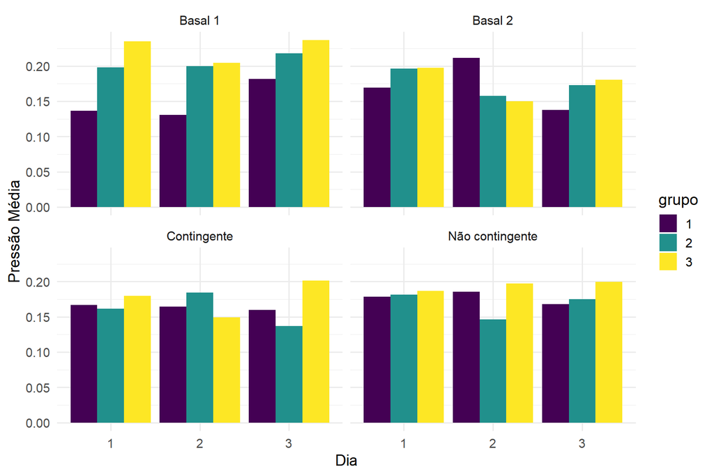

Nas condições Contingente e Não Contingente, nas quais existe um estímulo visual, a pressão média é um pouco menor do que nas Basais e não parece existir relação entre a Pressão e a Grupo (idade), porque não observamos nenhum padrão de crescimento ou queda nas imagens. Isso pode indicar uma resposta parecida ao estímulo, independentemente da idade.

## 6.5 Frequência de apertos

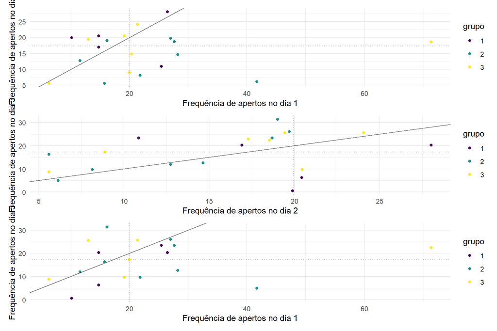

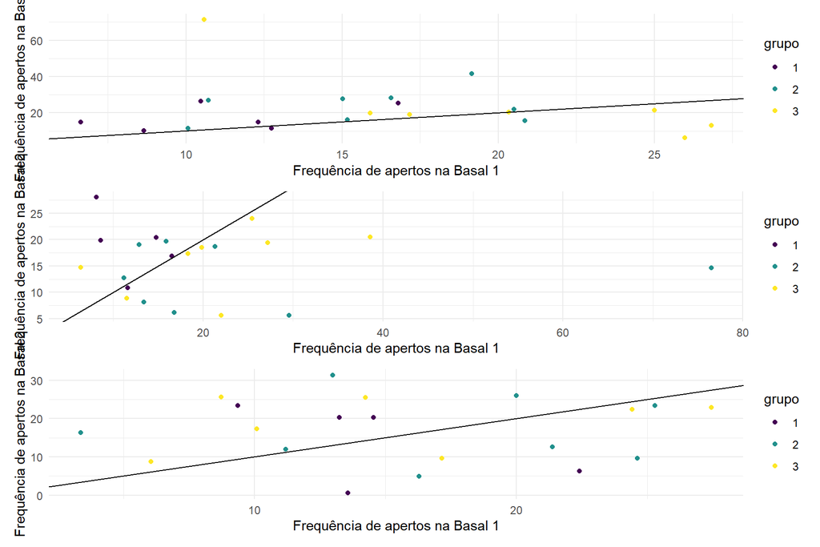

# 7 Metodologia

Nessa seção apresentamos a análise inferencial com o intuito de caracterizar o desenvolvimento da ação manipulativa de apertar em bebês. Devido as limitações encontradas no projeto, foram exploradas metodologias de inferência paramétrica e não paramétrica. A seguir, serão apresentadas os métodos aplicados aos dados do estudo.

## 7.1 Análise paramétrica

Primeiramente, analisamos a variável tempo entre apertos a fim de entender se a mesma se ajusta a uma distribuição exponencial. Essa é frequentemente usada para modelar o tempo entre eventos que ocorrem a uma taxa média constante.

Fixado um dia e condição do experimento, para cada bebê foram construidos histogramas da variável citada acima. Observamos que, para alguns participantes, o gráfico não apresentava o comportamento de decaimento esperado para dados cuja distribuição é exponencial. A fim de verificar se de fato a suposição é rejeitada, foi utilizado o teste de Kolmogorov-Smirnov, cuja hipótese nula define que a amostra de interesse é retirada da distribuição de referência.

Para a maioria dos bebês observados os testes rejeitaram a hipótese de exponencialidade dado por:

$$H_{0}: Tempo_{ijk} \sim Exponencial(\alpha_{ijk})$$
$$H_{1}: Tempo_{ijk} \not\sim Exponencial(\alpha_{ijk})$$

tal que $i$ = i-ésimo bebê, $j$ = j-ésimo dia de $k$ = k-ésima condição

Dado que a distribuição exponencial é a única dentre as contínuas com a característica de perda de memória - a chegada de uma ocasião é independente do evento anterior - esse resultado pode ser um indício de que os apertos não ocorrem a uma taxa média constante. Ou seja, parece existir um possível aprendizado entre os participantes do estudo, pois um aperto depende dos anteriores.

## 7.2 Análise não paramétrica

Em conversa com a pesquisadora determinamos que a variável de maior interesse para o estudo é a frequência de apertos, visto que ela caracteriza a quantidade de apertos em relação ao tempo de cada sessão. Como explicado anteriormente, houve interrupção de coleta e cortes nos dados de alguns bebês, ocasionando uma variação nos tempos de experimento em cada condição.

Conforme apontado na literatura (Wolfowitz, 1942) devemos nos referir a situação onde uma distribuição é completamente determinada pelo conhecimento de seu conjunto de parâmetros finitos como o caso paramétrico, e denotar o caso oposto, onde as formas funcionais das distribuições são desconhecidas, como o caso não paramétrico. Logo, como não foi possível identificar uma distribução conhecida para os dados propostos, decidimos seguir com testes não paramétricos.

### 7.2.1 Teste de Wilcoxon

O primeiro teste escolhido é frequentemente usado no lugar do Teste t (paramétrico) quando as populações comparadas não são normalmente distribuídas. Ou seja, a hipótese nula pode ser definida da seguinte forma:

$$H_0: a\; mediana\; das\; diferenças\;é\; zero = as\;duas\; populações\; são\; iguais \\
H_1: caso\; contrário$$

Primeiramente, são calculadas as diferenças entre a variável dos dados pareados:

$$|D_i| = |Y_i - X_i|$$
com $i$ = 1,2…$n^{'}$

Omitimos da análise os pares nos quais $D_i$ são nulos. Em seguida, atribui-se postos $R_i$ para cada valor, com $R_i$ = 1 o par com o menor valor de $|D_i|$ e $R_i$ = $n$ o par com o maior valor de $D_i$. No caso em que vários postos têm o mesmo valor de $|D_i|$, trabalha-se com postos médios.

Por fim, a estatística $T = \sum^{n}_{i=1}R_i$ é calculada e rejeita-se a hipótese nula ao nível de significância $\alpha$ se $T > W_{1-\alpha/2}$ ou $T < W_{alpha/2}$, onde $ W_{1-/2}$ e $W_{\alpha/2}$ são os quantis da estatística de Wilcoxon.

Obs: $n \leq n^{'}$ = quantidade de diferenças não nulas e $R_i = Posto(|D_i|)$

Algumas suposições do teste Wilcoxon são:

- Os dados não podem ser nominais;
- As diferenças $D_i$ têm distribuição simétrica;
- As diferenças $D_i$ são independentes e têm todos a mesma mediana

### 7.2.2 Interpretação dos resultados

No contexto do trabalho, a ideia era comparar entre os dias do experimento a diferença da frequência de apertos nas condições basal 1 e basal 2. Temos uma amostra de dados pareados pois são observados os mesmos bebês em diferentes dias do experimento.

Para uma melhor compreensão dos resultados, a variável de interesse foi transformada na variação da frequência de apertos da basal 1 e basal 2.

$$X_i = (\frac{freq_{(basal_2)} - freq_{(basal_1)}}{freq_{(basal_1)}} )$$

$$Y_i = (\frac{freq_{(basal_2)} - freq_{(basal_1)}}{freq_{(basal_1)}} )$$

Assim, o teste compara a diferença da variação percentual entre as sessões do experimento. Quando algum dos bebês não apresentam dados para determinado dia e condição, o algoritmo exclue a observação automaticamente.

```
FALSE
FALSE   Wilcoxon signed rank exact test
FALSE
FALSE data:  d1 and d2
FALSE V = 150, p-value = 0.09731
FALSE alternative hypothesis: true location shift is not equal to 0
```

```
FALSE
FALSE   Wilcoxon signed rank exact test
FALSE
FALSE data:  d1 and d2
FALSE V = 105, p-value = 0.7086
FALSE alternative hypothesis: true location shift is not equal to 0
```

```
FALSE
FALSE   Wilcoxon signed rank exact test
FALSE
FALSE data:  d1 and d2
FALSE V = 78, p-value = 0.33
FALSE alternative hypothesis: true location shift is not equal to 0
```

Ao analisar a comparação dos dias 1 e 3 observa-se que há indicios de igualdade entre as medianas das populações (valor-p = 0.709). O mesmo ocorre quando comparamos os dias 2 e 3 do experimento (valor-p = 0.330). Ou seja, nesses dois casos os dados indicam que não há diferença entre as condições basal 1 e basal 2 de uma sessão para a outra (?).